# Modelo Ingreso

Teresa Ortiz

8/2/2018

Descripción del modelo de ingreso.

### Datos

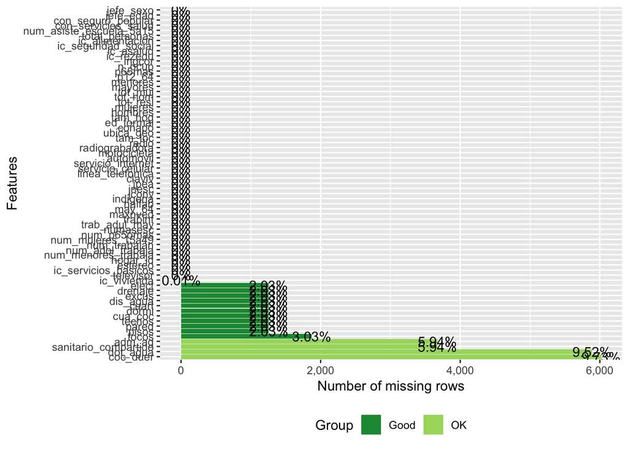

```r
faltantes <- DataExplorer::plot_missing(enigh_2010)
```

Y los podemos dividir en faltantes por lógica de cuestionario:

- cua_coc = 2 -> coc_duer = NA
- dis_agua %in% 3:6 -> dot_agua = NA
- excus = 2 -> sanitario_compartido = NA & adm_ag = NA
- elect = 5 -> focos = NA

Y 2.0% de faltantes restantes, en las siguientes preguntas:

```r
faltantes %>%
  filter(num_missing == 1253)
```

```
## # A tibble: 9 x 4
##   feature  num_missing pct_missing group
##   <fct>          <int>       <dbl> <chr>
## 1 pared           1253      0.0203 Good
## 2 techos          1253      0.0203 Good
## 3 cua_coc         1253      0.0203 Good
## 4 dormi           1253      0.0203 Good
## 5 cuart           1253      0.0203 Good
## 6 dis_agua        1253      0.0203 Good
## 7 excus           1253      0.0203 Good
## 8 drenaje         1253      0.0203 Good
## 9 elect           1253      0.0203 Good
```

Notamos que los faltantes de la tabla anterior pertenecen a 1253 hogares, repartidos en 401 municipios.

```r
enigh_faltantes <- enigh_2010 %>%
  mutate(faltante = is.na(pared) & is.na(techos))

enigh_faltantes %>%
  group_by(ubica_geo) %>%
  summarise(porcent_faltantes = 100 * sum(faltante) / n()) %>%
  filter(porcent_faltantes > 0) %>%
  arrange(desc(porcent_faltantes)) %>%
  top_n(20, porcent_faltantes)
```

```
## # A tibble: 20 x 2
##    ubica_geo porcent_faltantes
##    <chr>                 <dbl>
##  1 20025                  23.5
##  2 29058                  22.2
##  3 29039                  20
##  4 16016                  18.8
##  5 20427                  18.2
##  6 29054                  18.2
##  7 15062                  17.4
##  8 12030                  16.7
##  9 21181                  16.7
## 10 20091                  15.4
## 11 24049                  15.4
## 12 11041                  14.3
## 13 14023                  14.3
## 14 20149                  14.3
## 15 21035                  14.3
## 16 21041                  14.3
## 17 07012                  14.0
## 18 28026                  13.9
## 19 15018                  13.6
## 20 20393                  13.6
```

### Faltantes MCAR (missing completely at random, o faltante totalmente al azar)?

Una variable es MCAR si la probabilidad de faltar es la misma para todas las unidades. Por ejemplo, si todos los encuestados deciden si contestar la pregunta de ingresos lanzando un dado y negándose a contestar si observa un 6. En el caso MCAR eliminar las observaciones con faltantes no genera un sesgo en la inferencia.

```r
faltante_fit <- glm((faltante == 0) ~ jefe_sexo + jefe_edad + total_personas +
    ic_rezedu + n_ocup, data = enigh_faltantes, family = binomial(link = "logit"))

summary(faltante_fit)
```

```
##
## Call:
## glm(formula = (faltante == 0) ~ jefe_sexo + jefe_edad + total_personas +
##     ic_rezedu + n_ocup, family = binomial(link = "logit"), data = enigh_faltantes)
##
## Deviance Residuals:
##     Min       1Q   Median       3Q      Max
## -3.3553   0.1366   0.1768   0.2215   0.4260
##
## Coefficients:
##                 Estimate Std. Error z value Pr(>|z|)
## (Intercept)     2.616674   0.064671  40.461  < 2e-16 ***
## jefe_sexo      -0.017198   0.084994  -0.202 0.839652
## jefe_edad       0.030999   0.001793  17.293  < 2e-16 ***
## total_personas -0.074229   0.019909  -3.728 0.000193 ***
## ic_rezedu       0.302543   0.087799   3.446 0.000569 ***
## n_ocup          0.250724   0.038919   6.442 1.18e-10 ***
## ---
## Signif. codes:  0 '***' 0.001 '**' 0.01 '*' 0.05 '.' 0.1 ' ' 1
##
## (Dispersion parameter for binomial family taken to be 1)
##
##     Null deviance: 12252  on 61846  degrees of freedom
## Residual deviance: 11648  on 61841  degrees of freedom
## AIC: 11660
##
## Number of Fisher Scoring iterations: 7
```

Por ahora se eliminarán los faltantes, sin embargo, en corridas futuras se propone:

1. En el caso de faltantes por lógica de cuestionario se creará un nuevo código.
2. El 2% de faltantes adicionales se eliminará.

### Variables en modelo

Variables a considerar y selección de muestra.

Consideramos un subconjunto de las variables disponibles:

```r
enigh_vars <- enigh_2010 %>%
  select(hogar_id, ubica_geo, jefe_sexo, pisos, dis_agua, excus, drenaje,
    servicio_celular, servicio_internet, automovil, tam_hog, n_ocup, conapo,
    tam_loc, ingcor, maxnved, indigena) %>%
  na.omit() %>%
  filter(ingcor > 0)
```

Y seleccionamos la muestra en dos partes:

1. Seleccionamos 500 municipios.
2. Seleccionamos 10,000 hogares dentro de los municipios del paso 1 (perdemos 2 municipios en el proceso y el tamaño de muestra varía a lo largo de los municipios.

```r
# seleccionar muestra (municipios y hogares)
set.seed(182791)
in_sample_mun_ids <- sample(unique(enigh_vars$ubica_geo), 500)
in_sample_ids <- enigh_vars %>%
  filter(ubica_geo %in% in_sample_mun_ids) %>%
  sample_n(10000) %>%
  pull(hogar_id)
```

### Modelo

El modelo a ajustar es:

```r
mod_ingreso_pred <- stan_model(file = "./src/ingreso_prediccion.stan")
```

[output not shown]

[output cut: 1984 more lines]

[output not shown]

```r
mod_ingreso_pred
```

```
## S4 class stanmodel 'ingreso_prediccion' coded as follows:
## data {
##   // datos observados
##   int n; //número de hogares
##   int n_mun; // número de municipios
##   int mh; //número de covariables nivel hogar
##   int mm; //número de covariables nivel municipio
##   real ingreso[n];
##   matrix[n, mh] x_hogar;
##   int municipio[n];
##   matrix[n_mun, mm] x_municipio;
##
##   // datos todos los hogares
##   int N; // número total de hogares
##   matrix[N, mh] x_todos_hogar; // covariables todos los hogares
##   int todos_municipio[N];
##   vector[N] in_sample_hogar; // indicadora hogar en muestra
##
##   // datos todos municipios
##   int N_mun; // numero total de municipios
##   matrix[N_mun, mm] x_todos_municipio;
##   vector[N_mun] in_sample_mun;
## }
##
## transformed data {
##   vector[n] log_ingreso;
##   log_ingreso = log(1. + to_vector(ingreso));
## }
##
## parameters {
##   real beta_0;
##   vector[mh] beta;
##   real<lower=0> sigma;
##   vector[n_mun] beta_mun_raw;
##   real<lower=0> sigma_mun;
##   vector[mm] alpha;
## }
##
## transformed parameters {
##   vector[n] reg_pred;
```

[output cut: 25 more lines]

```
##   for(j in 1:N_mun){
##     if(in_sample_mun[j]==1){
##       beta_out[j] = beta_mun[j];
##     } else {
##       beta_out[j] = normal_rng(dot_product(x_todos_municipio[j,], alpha), sigma_mun);
##     }
##   }
##   for(k in 1:N){
##     if(in_sample_hogar[k]==1){
##       log_ingreso_out[k] = log_ingreso[k];
##     } else {
##       log_ingreso_out[k] = normal_rng(beta_0 + x_todos_hogar[k, ] * beta + beta_out[todos_municipio[k]], sigma);
##     }
##   }
## }
```

Para ajustar el modelo, creamos una función que lee la tabla de datos y regresa una lista con los datos a usar en el ajuste del modelo.

```r
# Recibe:
# datos_enigh: los datos enigh y un vector con los hogares seleccionados en la muestra
# de entrenamiento identificados por la varibale hogares_id
# Regresa en forma de lista:
# datos_modelo: lista para usar directamente en Stan, define datos del modelo.
# ind_mun: índice de clave de municipio e índice correspondiente en modelo.
# covs_mun: incluir covariables en efecto de municipio
preparar_datos <- function(datos_enigh, in_sample_ids, covs_mun = TRUE){
  datos_limpios_hogar <- datos_enigh %>%
    mutate(
      jefe_sexo = jefe_sexo,
      pisos = as.numeric(pisos != 1),
      dis_agua = as.numeric(dis_agua == 1),
      excus = as.numeric(excus == 1),
      drenaje = as.numeric(drenaje!=5),
      servicio_celular =  as.numeric(servicio_celular == 1),
      servicio_internet = as.numeric(servicio_internet == 1),
      automovil = as.numeric(automovil == 1),
      tam_hog = log(1+tam_hog),
      n_ocup = log(1+n_ocup),
      max_ed = log(maxnved),
      max_ed = ifelse(is.na(max_ed), 1, max_ed),
      in_sample = hogar_id %in% in_sample_ids
      ) %>%
    arrange(desc(in_sample))
  x_hogar <- model.matrix(~ jefe_sexo + pisos + dis_agua + excus +
      drenaje + servicio_celular + servicio_internet + automovil + tam_hog +
      n_ocup + max_ed + n_ocup * max_ed + factor(tam_loc) + indigena,
      data = datos_limpios_hogar)
  x_hogar <- x_hogar[, colnames(x_hogar) != "(Intercept)"]
  datos_mun <- datos_limpios_hogar %>%
    group_by(ubica_geo) %>%
    summarise(
      conapo = first(conapo),
      tam_mun = floor(median(tam_loc)),
      in_sample_mun = sum(in_sample) > 0
      ) %>%
      ungroup() %>%
    mutate(
      geo_id = str_c(1 - in_sample_mun, ubica_geo),
      geo_id = as.numeric(factor(geo_id))
      ) %>%
    arrange(desc(in_sample_mun), geo_id)
  if (covs_mun) {
    x_mun <- model.matrix(~ factor(tam_mun) * factor(conapo),
    data = datos_mun)
    x_mun <- x_mun[, colnames(x_mun) != "(Intercept)"]
  } else {
    x_mun <- model.matrix(~ -1 + factor(conapo), data = datos_mun)
  }
  ind_mun <- select(datos_mun, ubica_geo, geo_id, in_sample_mun)
  datos_limpios_hogar <- datos_limpios_hogar %>%
    left_join(ind_mun, by = "ubica_geo")
  n <- sum(datos_limpios_hogar$in_sample)
  n_mun = sum(datos_mun$in_sample_mun)
  datos_modelo <- list(
    n = n,
    n_mun = n_mun,
    mh = ncol(x_hogar),
    mm = ncol(x_mun),
    ingreso = datos_limpios_hogar$ingcor[1:n],
    x_hogar = x_hogar[1:n, ],
    x_municipio = x_mun[1:n_mun, ],
    municipio = datos_limpios_hogar$geo_id[1:n],
    N = nrow(datos_limpios_hogar),
    todos_municipio = datos_limpios_hogar$geo_id,
    x_todos_hogar = x_hogar,
    in_sample_hogar = as.numeric(datos_limpios_hogar$in_sample),
    N_mun = nrow(x_mun),
    x_todos_municipio = x_mun,
    in_sample_mun = as.numeric(datos_mun$in_sample_mun)
    )
  return(list(datos_modelo = datos_modelo, ind_mun = ind_mun,
    datos_hogar = datos_limpios_hogar,
    log_ingreso = log(datos_limpios_hogar$ingcor + 1)))
}

datos <- preparar_datos(datos_enigh = enigh_vars, in_sample_ids = in_sample_ids,
  covs_mun = FALSE)

# fit <- sampling(mod_ingreso_pred, data = datos$datos_modelo, chains = 2,
#   cores = 2, iter = 700, warmup = 400, control=list(max_treedepth=13))
# save(fit, file = "fit.RData")
load("fit.RData")
```

Ahora revisaremos diagnósticos de convergencia y *pp-checks* esto se puede hacer con el paquete `shinystan`.

```r
log_ingreso <- log(1 + datos$datos_modelo$ingreso)
shinystan::launch_shinystan(fit)
```

### Diagnósticos de convergencia

Trazas

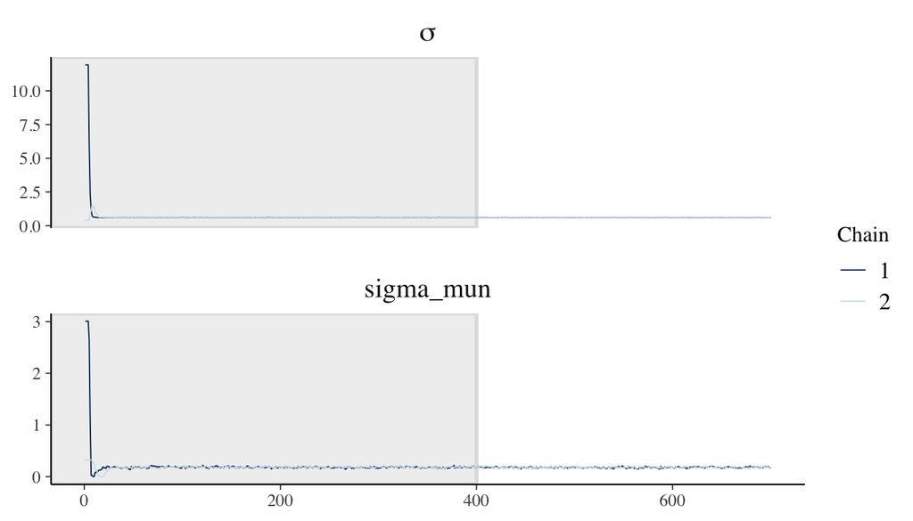

```r
library(bayesplot)
posterior <- extract(fit, inc_warmup = TRUE, permuted = FALSE)

color_scheme_set("mix-blue-pink")
p <- mcmc_trace(posterior,  pars = c("sigma", "sigma_mun"), n_warmup = 400,
  facet_args = list(nrow = 2, labeller = label_parsed, scales = "free_y"))
p + facet_text(size = 15)
```

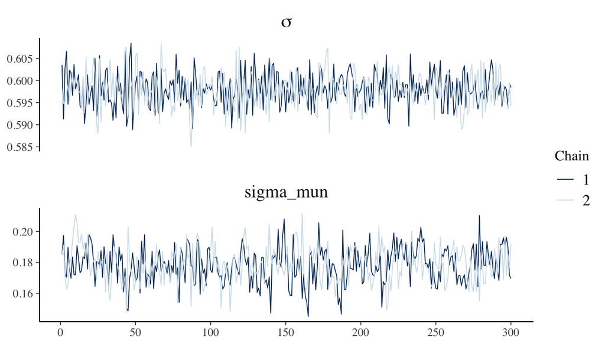

```r
library(bayesplot)

posterior <- extract(fit, inc_warmup = FALSE, permuted = FALSE)

p <- mcmc_trace(posterior,  pars = c("sigma", "sigma_mun"), n_warmup = 0,
  facet_args = list(nrow = 2, labeller = label_parsed, scales = "free_y"))
p + facet_text(size = 15)
```

### Diagnósticos tradicionales

### Trazas

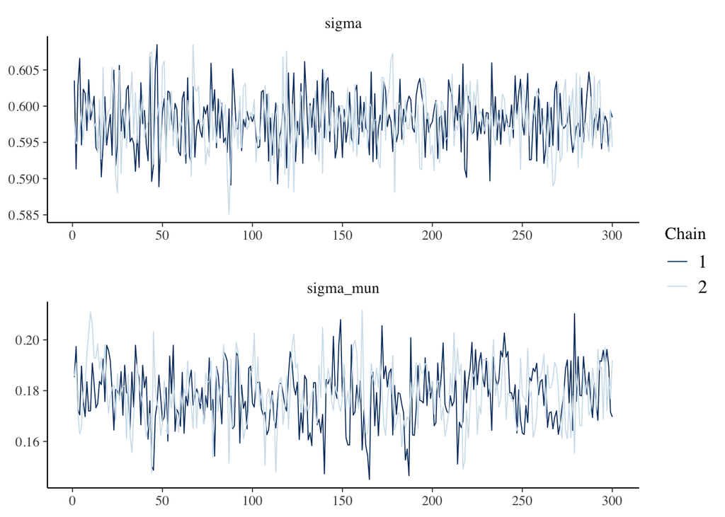

```r
library(bayesplot)
posterior <- as.array(fit)
mcmc_trace(posterior, pars = c("sigma", "sigma_mun"),
           facet_args = list(nrow = 2))
```

#### $\hat{R}$

$\hat{R}$ es una estadística de reducción potencial de escala, mide el cociente de la varianza promedio en las simulaciones de cada cadena respecto a la varianza de todas las cadenas juntas. La idea es que si todas la cadenas han alcanzado un estado de equilibrio, el numerador y denominador serán iguales y $\hat{R}$ será uno, de lo contrario será mayor a uno (Gelman et al. 2013, Stan Development Team 2018)).

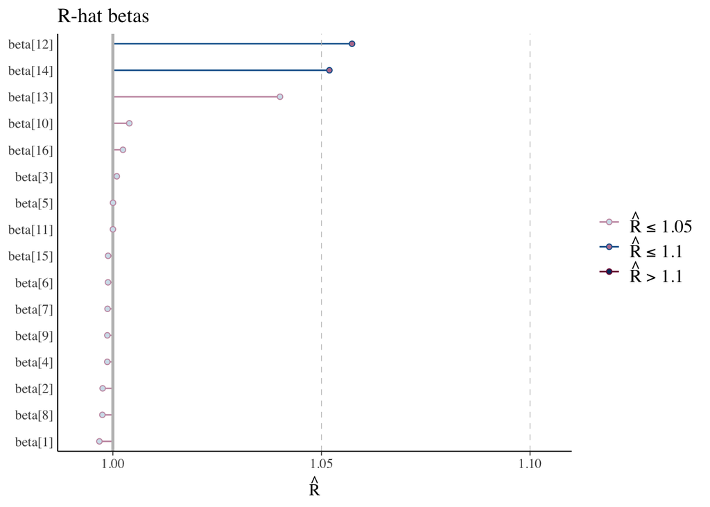

```r
rhats_betas <- rhat(fit, pars = "beta")
mcmc_rhat(rhats_betas) + ggtitle("R-hat betas") + yaxis_text(hjust = 1)
```

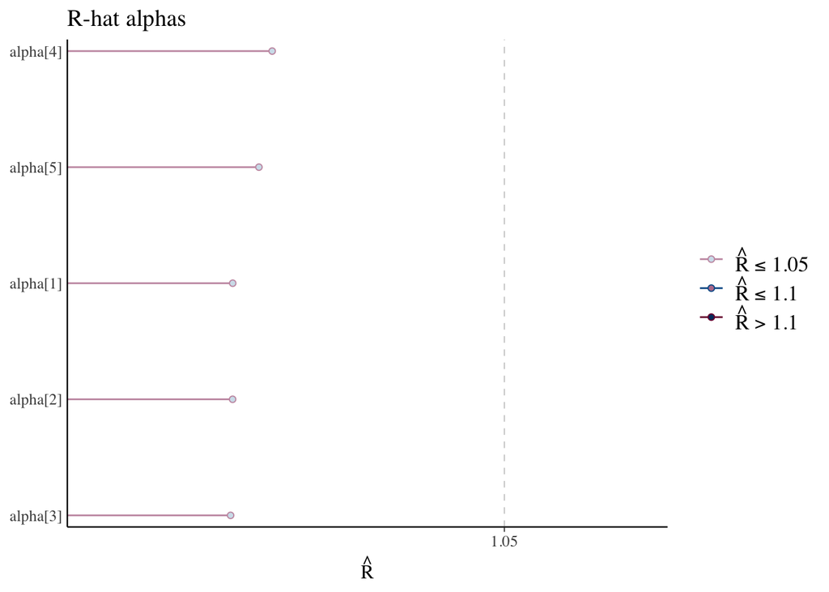

```r
rhats_alphas <- rhat(fit, par = "alpha")
mcmc_rhat(rhats_alphas) +
  ggtitle("R-hat alphas") + yaxis_text(hjust = 1)
```

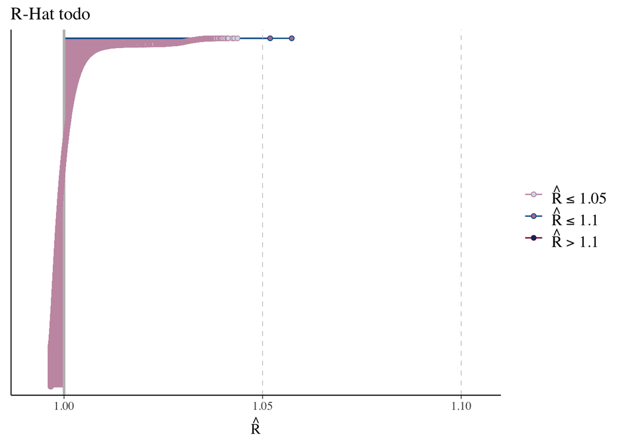

```r
rhats <- rhat(fit)
mcmc_rhat(rhats) + ggtitle("R-Hat todo")
```

#### Tamaño de muestra efectivo

El tamaño de muestra efectivo es una estimación del número de simulaciones independientes de la distribución posterior del estimador de interés. El valor $N_{eff}$ de Stan esta basado en la habilidad de las simulaciones en estimar la media del parámetro, que está relacionado (más no es necesariamente equivalente) con estimar otras funciones de los parámetros. Debido a que las simulaciones en una cadena de Markov no son independientes si autocorrelación, el tamaño de muestra efectivo $N_{eff}$ suele ser menor que el tamaño de muestra total $N$. Por tanto, entre mayor el cociente de $N_eff$ a $N$ mejor.

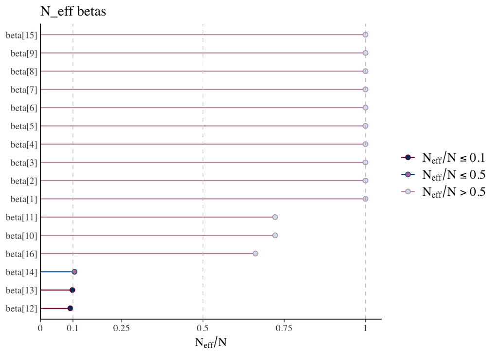

```r
ratios <- neff_ratio(fit, pars = "beta")
mcmc_neff(ratios, size = 2) + ggtitle("N_eff betas") + yaxis_text(hjust = 1)
```

Una convención usual (aunque arbitraria) es preocuparnos solo si$N_{eff} / N$ es menor a 0.1.

#### Autocorrelación

Como vimos arriba $N_{eff}/N$ disminuye cuando hay autocorrelación en las simulaciones. Otra manera de visualizar esto es haciendo gráficas de autocorrelación. La autocorrelación postitva es indeseable pues significa que la cadena tiende a quedarse en la misma región entre iteraciones, lo ideal en las siguientes gráficas es ver que cae a cero rápidamente conforme aumenta la dustancia. La autocorrelación negativa también es posible y es útil pues indica convergencia rápida de la media muestral a la media verdadera.

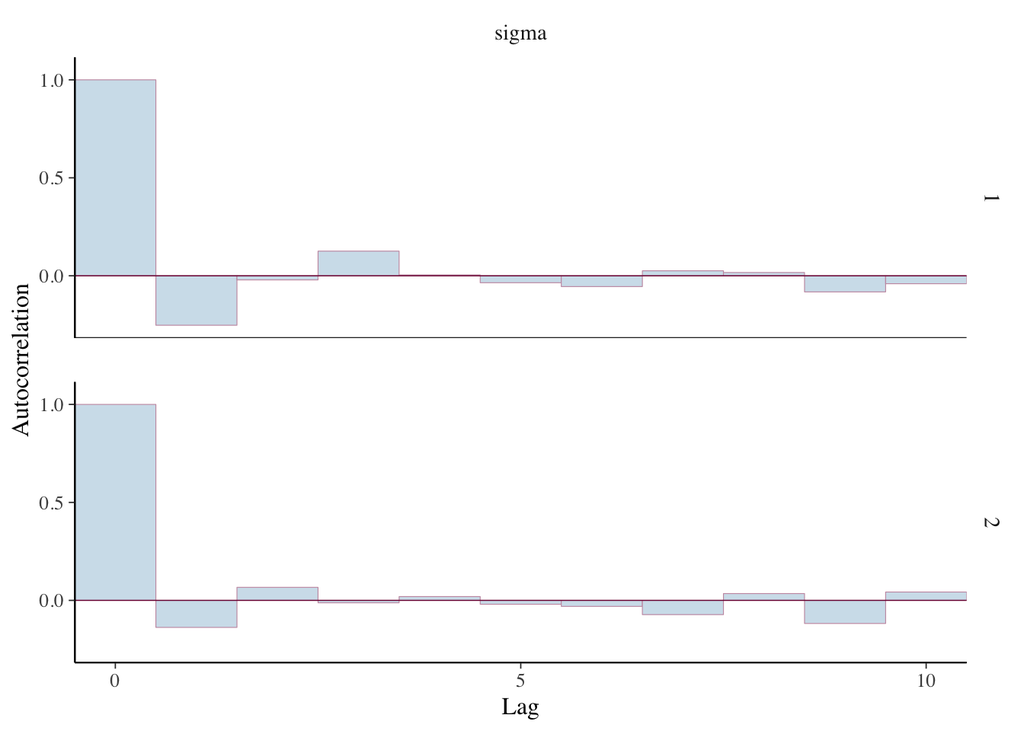

```r
mcmc_acf_bar(posterior, pars = "sigma", lags = 10)
```

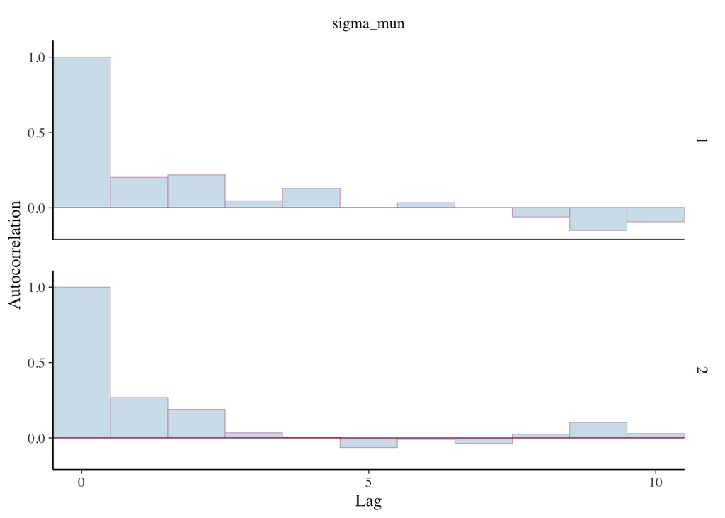

```r
mcmc_acf_bar(posterior, pars = "sigma_mun", lags = 10)
```

### No-U-Turn Sampler

Para los diagnósticos de NUTS se utiliza la log-posterior de cada simulación y algunos diagnósticos específicos del muestreador.

```r
lpost <- log_posterior(fit)
head(lpost)
```

```
##   Iteration      Value Chain
## 1         1  -66.42519     1
## 2         2  -65.45613     1
## 3         3 -108.18567     1
## 4         4 -121.61258     1
## 5         5  -93.08815     1
## 6         6 -102.50976     1
```

```r
nuts_p <- nuts_params(fit)
head(nuts_p)
```

```
##   Iteration     Parameter     Value Chain
## 1         1 accept_stat__ 0.9998656     1
## 2         2 accept_stat__ 0.9629576     1
## 3         3 accept_stat__ 0.8714179     1
## 4         4 accept_stat__ 0.9707202     1
## 5         5 accept_stat__ 0.9954787     1
## 6         6 accept_stat__ 0.7868023     1
```

Las gráficas asociadas a NUTS sirven para analizar las divergencias, sin embargo, en este ajuste no tuvimos divergencias.

### Estiamaciones

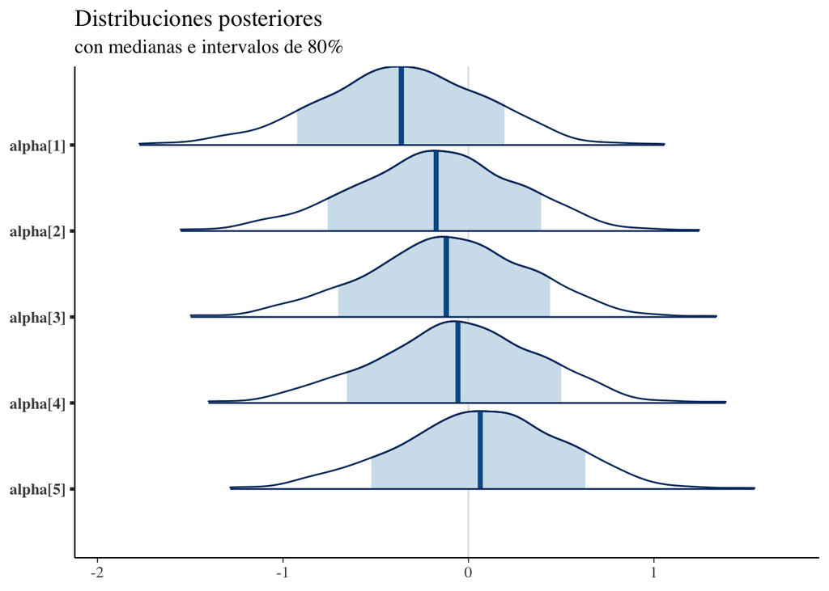

```r
mcmc_areas(posterior, regex_pars = c("alpha"), prob = 0.8) +
  ggtitle("Distribuciones posteriores", "con medianas e intervalos de 80%")
```

### PP-checks

Cuando hablamos de *posterior predictive checks* lo que buscamos es comparar los datos observados con datos simulados de la distribución predictiva posterior. La idea detras de *pp-checks* es que si el modelo ajusta bien a los datos entonces debería de poder generar datos que se parezcan a los datos observados.

$$p(\tilde{y}|y)=\int p(\tilde{y}|\theta)p(\theta|y)d\theta$$

En la ecuación de arriba podemos condicionar también a una matriz de covariables $X$.

Computacionalmente, lo que haremos es que para cada simulación $s=1,...,S$ de los parámetros de la distribución posterior $\theta^{(s)}\sim p(\theta|y)$ obtenemos un vector $\tilde{y}^{(s)}$ de tamaño $N$ de la distribución predictiva posterior usando el modelo ($p(y|\theta)$) y condicionando a los parámetros $\theta^(s)$. Como resultado tenemos una matriz de simualciones de $\tilde{y}$ de tamaño $S \times N$.

Cuando simulamos de la distribución predictiva posterior podemos usar los mismos valores de la matriz de covariables $X$ que usamos al ajustar el modelo o podemos simular para nuevas observaciones con sus covariables $\tilde{X}$ correspondiente. En el primer caso denotamos las replicaciones $y^{rep}$ pues las podemos considerar replicaciones de la variable respuesta $y$ más que predicciones de observaciones futuras ($\tilde{y}$ con covariables $\tilde{X}$).

En la siguiente gráfica la línea obscura es la distribución del log-ingreso observado en la muestra de 10,000 hogares, y cada una de las líneas claras es una replicación del log-ingreso simulada de la distribución predictiva posterior (estimaciones de densidad por kernel).

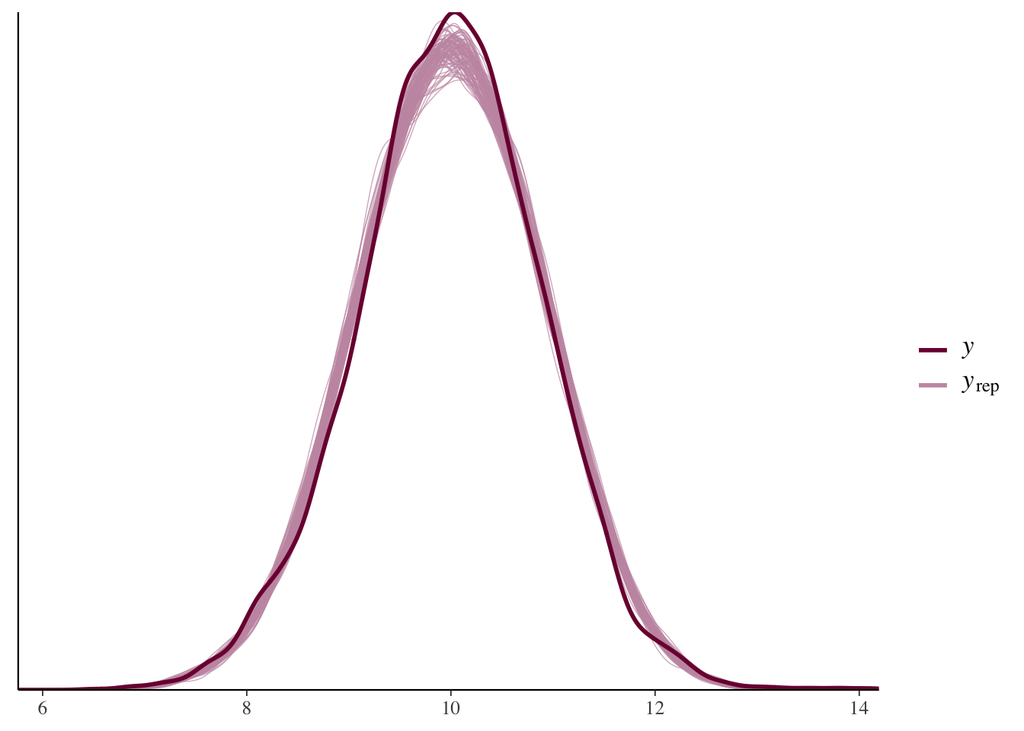

```r
y <- log(1 + datos$datos_modelo$ingreso)
y_rep <- extract(fit, "log_reps")[[1]]

ppc_dens_overlay(y, y_rep[1:100, ])
```

Podemos ver la misma información en histogramas.

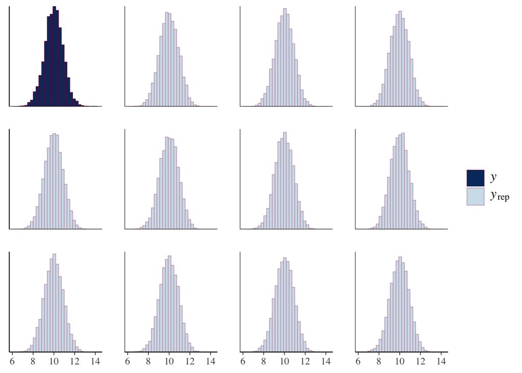

```r
ppc_hist(y, y_rep[1:11, ])
```

Además de comparar la distribución podemos comparar estadísticas y comparar las estadísticas evaluadas en los datos observados con los correspondientes a las replicaciones.

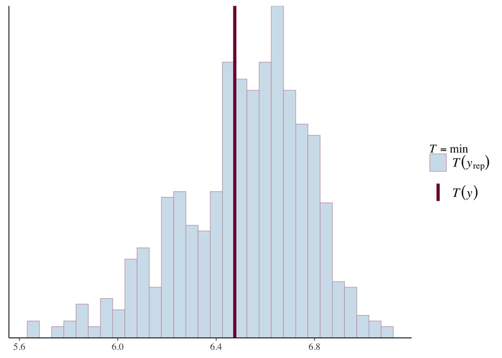

```r
ppc_stat(y, y_rep, stat = "min")
```

El máximo en los datos no parece congruente con el modelo.

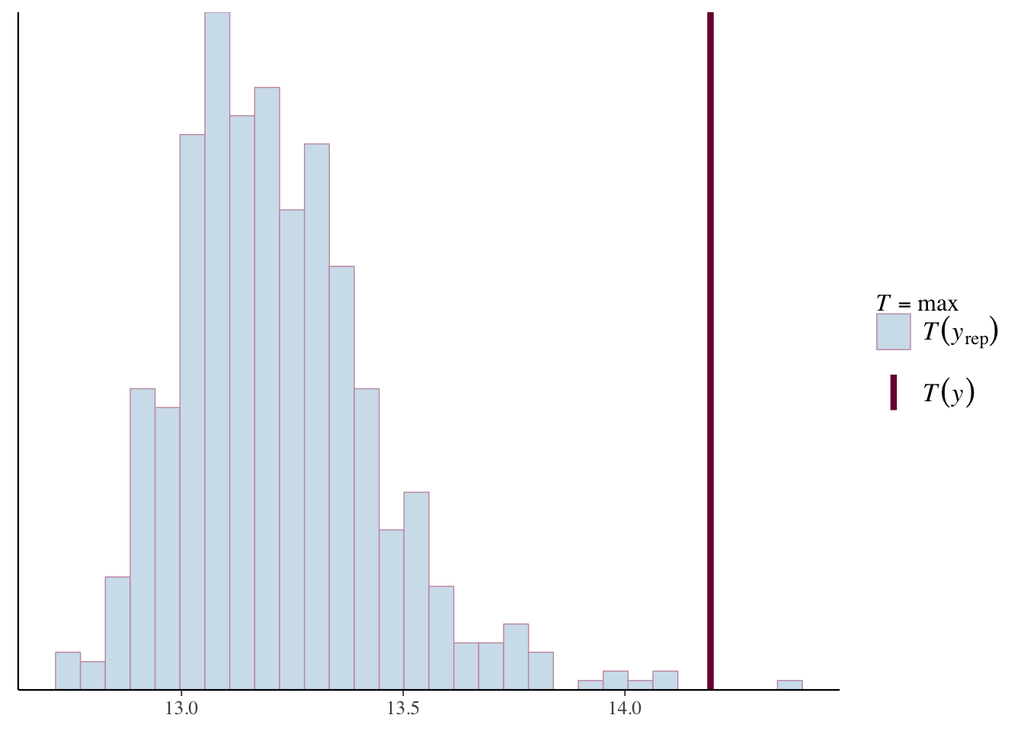

```r
ppc_stat(y, y_rep, stat = "max")
```

También podemos graficar intervalos y ver si contienen al verdadero valor, el default es construir intervalos del 90%.

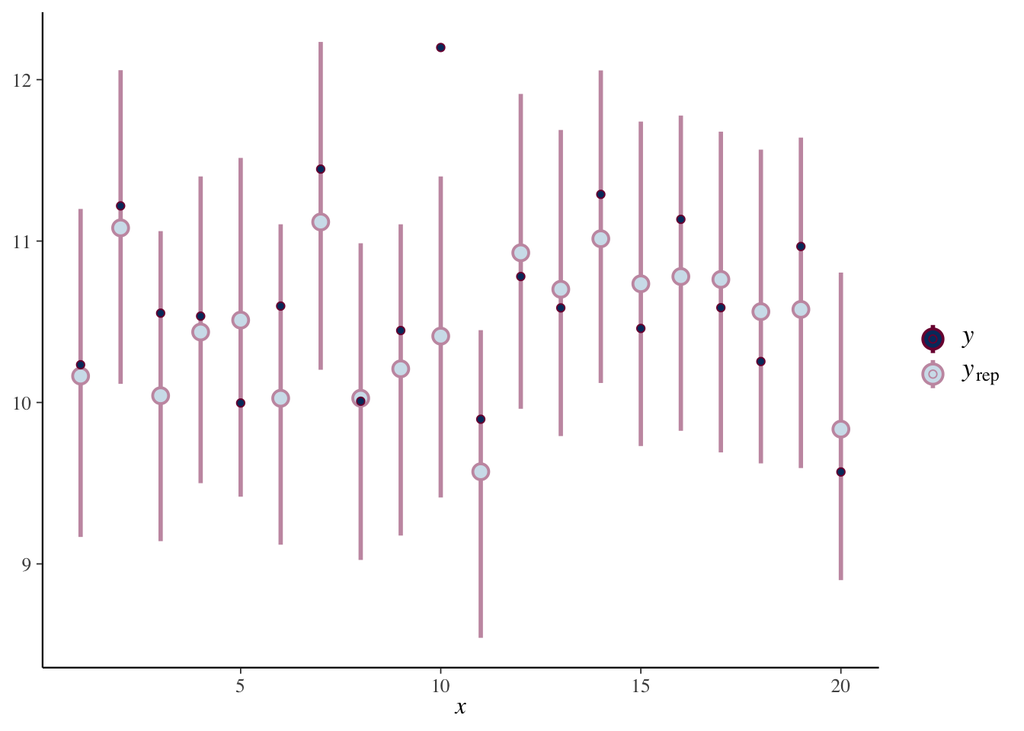

```r
inds <- sample(1:1000, 20)
ppc_intervals(y[inds], y_rep[, inds])
```

El paquete bayesplot contiene muchas herramientas más para hacer *pp-checks*.

```r
available_ppc()
```

```
## bayesplot PPC module:
##   ppc_bars
##   ppc_bars_grouped
##   ppc_boxplot
##   ppc_data
##   ppc_dens
##   ppc_dens_overlay
##   ppc_ecdf_overlay
##   ppc_error_binned
##   ppc_error_hist
##   ppc_error_hist_grouped
##   ppc_error_scatter
##   ppc_error_scatter_avg
##   ppc_error_scatter_avg_vs_x
##   ppc_freqpoly
##   ppc_freqpoly_grouped
##   ppc_hist
##   ppc_intervals
##   ppc_intervals_data
##   ppc_intervals_grouped
##   ppc_loo_intervals
##   ppc_loo_pit
##   ppc_loo_pit_overlay
##   ppc_loo_pit_qq
##   ppc_loo_ribbon
##   ppc_ribbon
##   ppc_ribbon_data
##   ppc_ribbon_grouped
##   ppc_rootogram
##   ppc_scatter
##   ppc_scatter_avg
##   ppc_scatter_avg_grouped
##   ppc_stat
##   ppc_stat_2d
##   ppc_stat_freqpoly_grouped
##   ppc_stat_grouped
##   ppc_violin_grouped
```

## Calibración

The Calibrated Bayesian (CB) approach to statistical inference capitalizes on the strength of Bayesian and frequentist approaches to statistical inference. In the CB approach, inferences under a particular model are Bayesian, but frequentist methods are useful for model development and model checking.

Comenzamos graficando intervalos para una muestra de 2000 hogares, graficando cada grado de marginación en un panel.

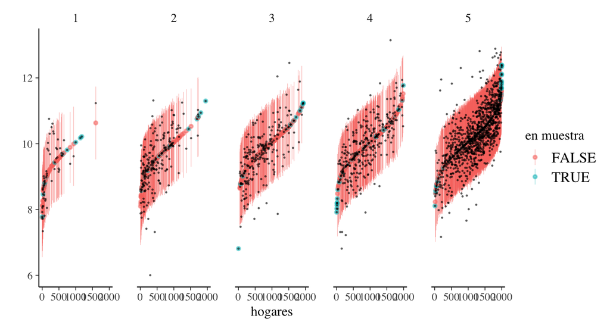

```r
log_ingreso_out <- extract(fit, "log_ingreso_out")[[1]]

log_ingreso <- as.data.frame(t(log_ingreso_out)) %>%
  mutate(hogar_id = 1:ncol(log_ingreso_out )) %>%
  gather(n_sim, value, contains("V")) %>%
  mutate(n_sim = parse_number(n_sim))

log_ingreso_df <- log_ingreso %>%
  group_by(hogar_id) %>%
  summarise(
    media = mean(value),
    mediana = median(value),
    desv_est = sd(value),
    q_inf = quantile(value, probs = 0.025),
    q_sup = quantile(value, probs = 0.975)
  ) %>%
  ungroup() %>%
  bind_cols(datos$datos_hogar) %>%
  mutate(y = datos$log_ingreso)


n_sample <- 2000
plot_sample <- sample_n(log_ingreso_df, size = n_sample) %>%
  arrange(media) %>%
  mutate(id = 1:n_sample)

ggplot(plot_sample, aes(x = id, y = media, ymin = q_inf,
  ymax = q_sup, color = factor(in_sample))) +
  geom_pointrange(alpha = 0.5, size = 0.2) +
  geom_point(aes(y = y), color = "black", size = 0.3, alpha = 0.5) +
  facet_wrap(~conapo, nrow=1) +
  labs(color = "en muestra", x = "hogares", y = "")
```

Y vemos coberturas:

```r
log_ingreso_df %>%
  filter(!in_sample) %>%
  mutate(
    cubre_90 = y > media - 1.64 * desv_est &
      y < media + 1.64 * desv_est,
    cubre_95 = y > media - 2 * desv_est &
      y < media + 2 * desv_est
    ) %>%
  summarise(
    cobertura_90 = 100 * mean(cubre_90),
    cobertura_95 = 100 * mean(cubre_95)
    )
```

```
## # A tibble: 1 x 2
##   cobertura_90 cobertura_95
##          <dbl>        <dbl>
## 1         90.8         95.0
```

```r
log_ingreso_df %>%
  filter(!in_sample) %>%
  group_by(conapo) %>%
  mutate(
    cubre_90 = y > media - 1.64 * desv_est &
      y < media + 1.64 * desv_est,
    cubre_95 = y > media - 2 * desv_est &
      y < media + 2 * desv_est
    ) %>%
  summarise(
    cobertura_90 = 100 * mean(cubre_90),
    cobertura_95 = 100 * mean(cubre_95)
    )
```

```
## # A tibble: 5 x 3
##   conapo cobertura_90 cobertura_95
##    <int>        <dbl>        <dbl>
## 1      1         88.7         94.1
## 2      2         90.2         94.6
## 3      3         90.7         95.0
## 4      4         90.4         94.5
## 5      5         91.2         95.2
```

Ahora veamos las medias municipales. Si consideramos la muestra de ENIGH como la población podemos evaluar el modelo analizando si cubrimos el valor *poblacional* del ingreso promedio a nivel municipio tanto adentro como afuera de la muestra.

```r
log_ingreso_mun <- log_ingreso %>%
  mutate(ingreso_est = exp(value)) %>%
  left_join(log_ingreso_df) %>%
  group_by(ubica_geo, n_sim) %>%
  summarise(
    n = n(),
    n_muestra = sum(in_sample),
    ing_medio = mean(ingreso_est),
    ingcor_medio = mean(ingcor),
    ingcor_mediana = median(ingcor),
    conapo = first(conapo)
    ) %>%
  group_by(ubica_geo) %>%
  summarise(
    media_est = mean(ing_medio),
    mediana_est = median(ing_medio),
    sd_est = sd(ing_medio),
    ingcor_medio = first(ingcor_medio),
    n_muestra = first(n_muestra),
    conapo = first(conapo)
  ) %>%
  mutate(n_muestra_cat = Hmisc::cut2(n_muestra, cuts = c(0, 5, 10, 50, 100, 500)))
```

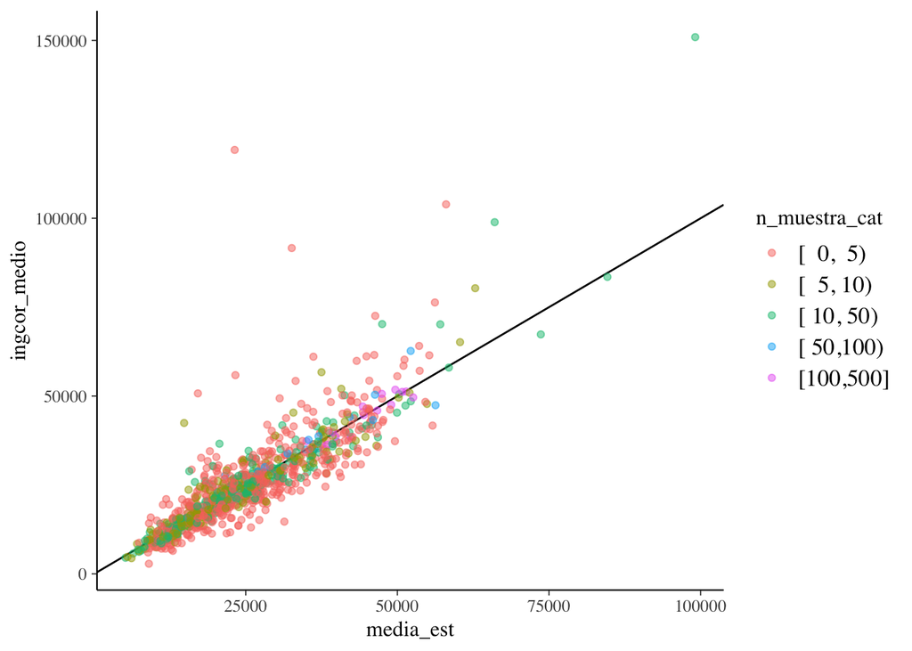

```r
ggplot(log_ingreso_mun, aes(x = media_est, y = ingcor_medio,
  color = n_muestra_cat)) +
  geom_abline() +
  geom_point(alpha = 0.5)
```

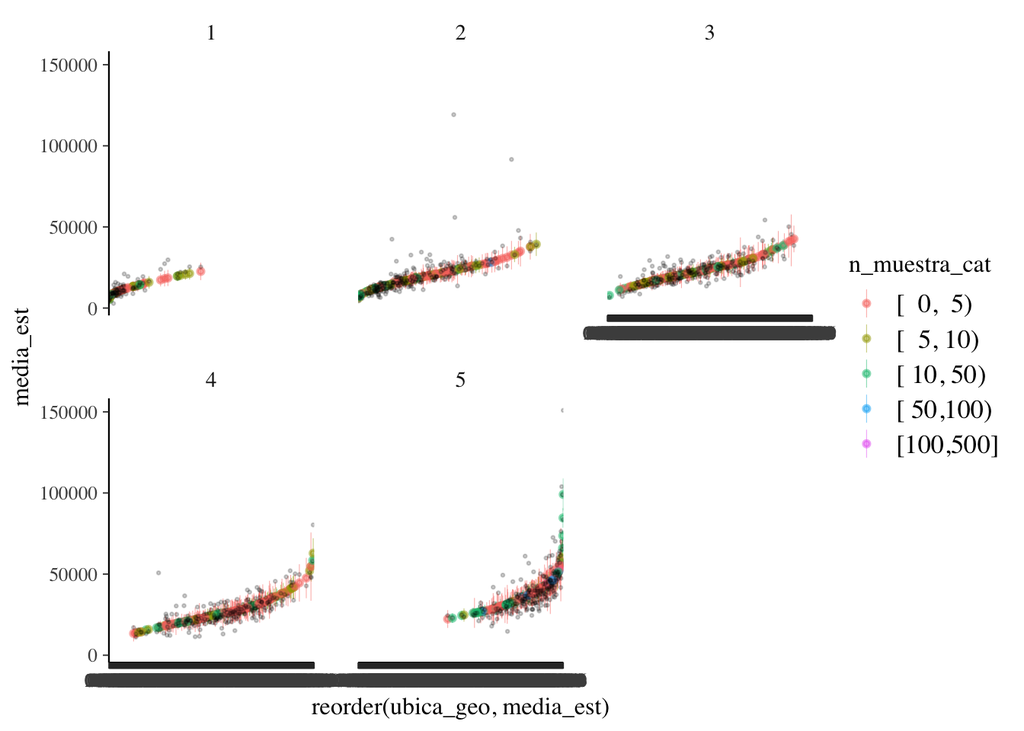

```r
ggplot(log_ingreso_mun, aes(x = reorder(ubica_geo, media_est),
  y = media_est, ymin = media_est - sd_est, ymax = media_est + sd_est,
  color = n_muestra_cat)) +
  geom_pointrange(alpha = 0.5, size = 0.2) +
  geom_point(aes(y = ingcor_medio), color = "black", alpha = 0.2, size = 0.5) +
  facet_wrap(~conapo)
```

Coberturas municipales

```r
log_ingreso_mun %>%
  mutate(
    cubre_90 = ingcor_medio > media_est - 1.64 * sd_est &
      ingcor_medio < media_est + 1.64 * sd_est,
    cubre_95 = ingcor_medio > media_est - 2 * sd_est &
      ingcor_medio < media_est + 2 * sd_est
    ) %>%
  summarise(
    cobertura_90 = 100 * mean(cubre_90),
    cobertura_95 = 100 * mean(cubre_95)
    )
```

```
## # A tibble: 1 x 2
##   cobertura_90 cobertura_95
##          <dbl>        <dbl>
## 1         89.3         94.3
```